# EDA

Zobaczmy ten sam proces przetwarzania danych, ale tym razem dla nie-guzka

```python
mhd_file = mhd_file2
ct_scan = ct_scan2
# Weź dane właściwego pacjenta. Bierzemy tylko jeden odczyt z danego pacjenta nawet jeżeli jest ich kilka
patient_data = df[df['seriesuid'] == filenames[1]].reset_index(drop=True).iloc[1]
patient_data
```

```
seriesuid      1.3.6.1.4.1.14519.5.2.1.6279.6001.323302986710...
coordX                                                -42.112938
coordY                                                 18.280812
coordZ                                                     10.16
diameter_mm                                                 -1.0
class                                                          0
Name: 1, dtype: object
```

```python
ct_scan_chunk = get_scan_chunk(ct_scan, patient_data)
ct_scan_chunk.shape
```

```
(10, 32, 32)
```

Zobaczmy jak wyglądają skany gdy tego guzka nie ma

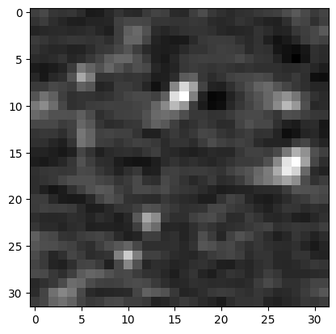

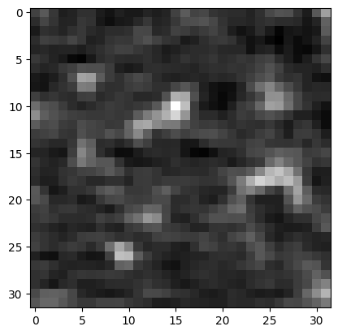

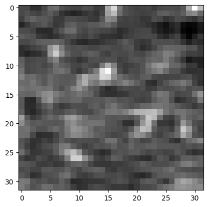

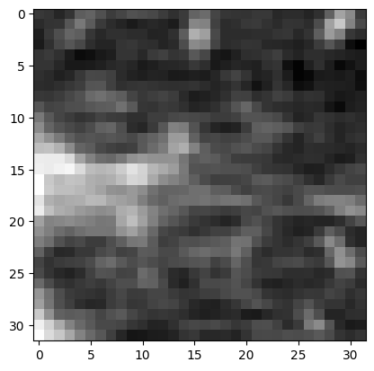

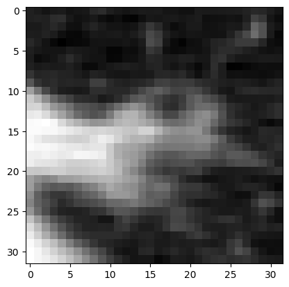

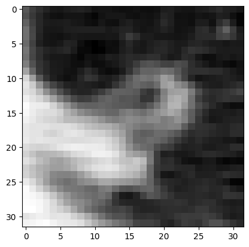

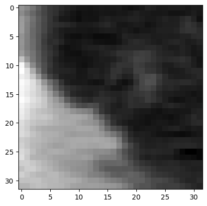

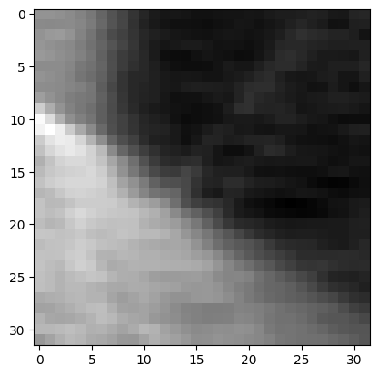

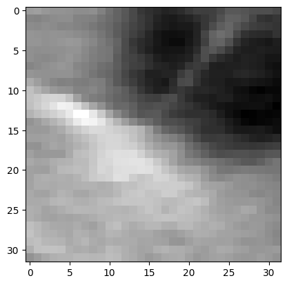

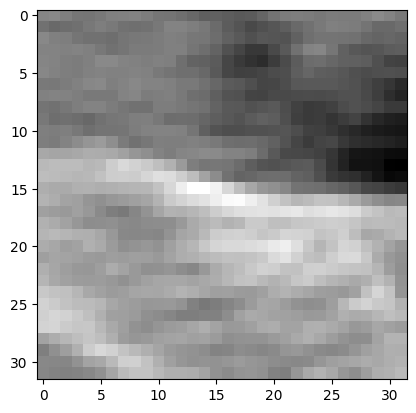

```python
for i in range(0, 10):
    plt.imshow(ct_scan_chunk[i], cmap='gray')
    plt.show()
```

Widzimy, że inaczej wyglądają oba skany. Znależliśmy więc efektywną metodę zmniejszenia wymiarowości danych tak żeby nie zatracić żadnej informacji

# Podsumowanie

Nasz problem jest tylko dotknięciem tematu wykrywania guzków płuc.

Jednak nasza analiza pozwoliła nam zauważyć kilka rzeczy:

1. Nasz problem jest niezbalansowany. Trzeba zwracać uwagę na to czy model rzeczywiście uczy się problemu czy tylko predykuje same nie-guzki
2. Warto uważać na potencjalny wyciek danych. Jeżeli zmieszamy dane o wszystkich guzkach i nie-guzkach to wówczas jest szansa, że ten sam pacjent znajdzie się w zbiorze treningowym i zbiorze walidacyjnym. Dla bezpieczeństwa najlepiej jeżeli jeden subset zostanie w całości przeznaczony na walidację (co też autorzy datasetu zalecają)
3. Mamy do czynienia z danymi medycznymi - trzeba bardzo uważać jak je przetwarzamy. Bardzo łatwo jest zrobić błąd w wyniku niewiedzy jak te dane działają
4. Jesteśmy w stanie znacząco zmniejszyć wymiarowość danych. Koniecznym krokiem będzie odpowiedni preprocessing tych danych, gdyż nie chcemy trzymać 60 GB danych na naszym dysku.